# Coronavirus US - CDC

davegoblue

10/25/2020

## Background

This is a subset of the code contained in Coronavirus_Statistics_v002.Rmd. This file includes the latest code for analyzing all-cause death data from [CDC Weekly Deaths by Jurisdiction](https://catalog.data.gov/dataset/weekly-counts-of-deaths-by-jurisdiction-and-age-group). CDC maintains data on deaths by week, age cohort, and state in the US. Downloaded data are unique by state, epidemiological week, year, age, and type (actual vs. predicted/projected).

These data are known to have a lag between death and reporting, and the CDC back-correct to report deaths at the time the death occurred even if the death is reported in following weeks. This means totals for recent weeks tend to run low (lag), and the CDC run a projection of the expected total number of deaths given the historical lag times. Per other analysts on the internet, there is currently significant supra-lag, with lag times much longer than historical averages causing CDC projected deaths for recent weeks to be low.

Functions are available in Coronavirus_Statistics_Functions_CDC_v003.R and Coronavirus_Statistics_Functions_Shared_v003.R. The code leverages tidyverse and a variable mapping file throughout:

```r
# All functions assume that tidyverse and its components are loaded and available
# Other functions are declared in the sourcing files or use library::function()
library(tidyverse)
```

```r
# If the same function is in both files, use the version from the more specific source
source("./Coronavirus_Statistics_Functions_Shared_v003.R")
source("./Coronavirus_Statistics_Functions_CDC_v003.R")

# Create a variable mapping file
varMapper <- c("cases"="Cases",
               "newCases"="Increase in cases, most recent 30 days",
               "casesroll7"="Rolling 7-day mean cases",
               "deaths"="Deaths",
               "newDeaths"="Increase in deaths, most recent 30 days",
               "deathsroll7"="Rolling 7-day mean deaths",
               "cpm"="Cases per million",
               "cpm7"="Cases per day (7-day rolling mean) per million",
               "newcpm"="Increase in cases, most recent 30 days, per million",
               "dpm"="Deaths per million",
               "dpm7"="Deaths per day (7-day rolling mean) per million",
               "newdpm"="Increase in deaths, most recent 30 days, per million",
               "hpm7"="Currently Hospitalized per million (7-day rolling mean)",
               "tpm"="Tests per million",
               "tpm7"="Tests per million per day (7-day rolling mean)"
               )
```

## Running Code

The main function is readRunCDCAllCause(), which performs multiple tasks:

STEP 0: Optionally, downloads the latest data file from CDC STEP 1: Reads and processes a data file has been downloaded from CDC to local  
STEP 2: Extract relevant data from a processed state-level COVID Tracking Project list  
STEP 3: Basic plots of the CDC data  
STEP 4: Basic excess-deaths analysis  
STEP 5: Create cluster-level aggregate plots  
STEP 6: Create state-level aggregate plots  
STEP 7: Create age-cohort aggregate plots  
STEP 8: Returns a list of key data frames, modeling objects, named cluster vectors, etc.

The main use case is to run the full CDC data download and analysis. An example is created, with the caveat that data are not repeatedly downloaded (process is cached) to avoid unnecessary calls to the CDC server.

Further, files can be saved in RDS format so they can be loaded and used later.

#### *Use Case: Download new data, analyze all-cause excess deaths*

The full process downloads data, and analyzes all-cause excess deaths:

```
## Rows: 177,312
## Columns: 11
## $ Jurisdiction         <chr> "Alabama", "Alabama", "Alabama", "Alabama", "A...
## $ `Week Ending Date`   <chr> "01/10/2015", "01/17/2015", "01/24/2015", "01/...
## $ `State Abbreviation` <chr> "AL", "AL", "AL", "AL", "AL", "AL", "AL", "AL"...
## $ Year                 <int> 2015, 2015, 2015, 2015, 2015, 2015, 2015, 2015...
## $ Week                 <int> 1, 2, 3, 4, 5, 6, 7, 8, 9, 10, 11, 12, 13, 14,...
## $ `Age Group`          <chr> "25-44 years", "25-44 years", "25-44 years", "...
## $ `Number of Deaths`   <dbl> 67, 49, 55, 59, 47, 59, 41, 47, 59, 57, 54, 50...
## $ `Time Period`        <chr> "2015-2019", "2015-2019", "2015-2019", "2015-2...
## $ Type                 <chr> "Predicted (weighted)", "Predicted (weighted)"...
## $ Suppress             <chr> NA, NA, NA, NA, NA, NA, NA, NA, NA, NA, NA, NA...
## $ Note                 <chr> NA, NA, NA, NA, NA, NA, NA, NA, NA, NA, NA, NA...
## Rows: 177,312
## Columns: 11
## $ Jurisdiction <chr> "Alabama", "Alabama", "Alabama", "Alabama", "Alabama",...
## $ weekEnding   <date> 2015-01-10, 2015-01-17, 2015-01-24, 2015-01-31, 2015-...
## $ state        <chr> "AL", "AL", "AL", "AL", "AL", "AL", "AL", "AL", "AL", ...
## $ year         <int> 2015, 2015, 2015, 2015, 2015, 2015, 2015, 2015, 2015, ...
## $ week         <int> 1, 2, 3, 4, 5, 6, 7, 8, 9, 10, 11, 12, 13, 14, 15, 16,...
## $ age          <chr> "25-44 years", "25-44 years", "25-44 years", "25-44 ye...
## $ deaths       <dbl> 67, 49, 55, 59, 47, 59, 41, 47, 59, 57, 54, 50, 58, 42...
## $ period       <chr> "2015-2019", "2015-2019", "2015-2019", "2015-2019", "2...
## $ type         <chr> "Predicted (weighted)", "Predicted (weighted)", "Predi...
## $ Suppress     <chr> NA, NA, NA, NA, NA, NA, NA, NA, NA, NA, NA, NA, NA, NA...
## $ Note         <chr> NA, NA, NA, NA, NA, NA, NA, NA, NA, NA, NA, NA, NA, NA...
##
## Check Control Levels and Record Counts for Renamed Data:
```

```
## # A tibble: 6 x 4
##   age                    n n_deaths_na   deaths
##   <chr>              <int>       <int>    <dbl>
## 1 25-44 years        26550           1  3241456
## 2 45-64 years        32429           7 12704920
## 3 65-74 years        32421          10 12597720
## 4 75-84 years        32439          12 15661806
## 5 85 years and older 32427          13 20427610
## 6 Under 25 years     21046           0  1398168
```

```
## # A tibble: 12 x 6
## # Groups:   period, year [6]
##    period     year type                     n n_deaths_na  deaths
##    <chr>     <int> <chr>                <int>       <int>   <dbl>
##  1 2015-2019  2015 Predicted (weighted) 15286           0 5416401
##  2 2015-2019  2015 Unweighted           15286           0 5416401
##  3 2015-2019  2016 Predicted (weighted) 15366           0 5483774
##  4 2015-2019  2016 Unweighted           15366           0 5483774
##  5 2015-2019  2017 Predicted (weighted) 15318           0 5643347
##  6 2015-2019  2017 Unweighted           15318           0 5643347
##  7 2015-2019  2018 Predicted (weighted) 15306           0 5698014
##  8 2015-2019  2018 Unweighted           15306           0 5698014
##  9 2015-2019  2019 Predicted (weighted) 15318           0 5725535
## 10 2015-2019  2019 Unweighted           15318           0 5725535
## 11 2020       2020 Predicted (weighted) 12087          26 5098636
## 12 2020       2020 Unweighted           12037          17 4998902
```

```
## # A tibble: 3 x 5
## # Groups:   period [2]
##   period    Suppress                                       n n_deaths_na  deaths
##   <chr>     <chr>                                      <int>       <int>   <dbl>
## 1 2015-2019 <NA>                                      153188           0  5.59e7
## 2 2020      Suppressed (counts highly incomplete, <5~     43          43  0.
## 3 2020      <NA>                                       24081           0  1.01e7
```

```
## # A tibble: 9 x 5
## # Groups:   period [2]
##   period   Note                                            n n_deaths_na  deaths
##   <chr>    <chr>                                       <int>       <int>   <dbl>
## 1 2015-20~ <NA>                                       153188           0  5.59e7
## 2 2020     Data in recent weeks are incomplete. Only~  19486           8  8.54e6
## 3 2020     Data in recent weeks are incomplete. Only~    396           0  1.85e5
## 4 2020     Data in recent weeks are incomplete. Only~    417          33  4.95e4
## 5 2020     Data in recent weeks are incomplete. Only~   1415           2  3.41e5
## 6 2020     Data in recent weeks are incomplete. Only~     48           0  2.27e4
## 7 2020     Estimates for Pennsylvania are too low fo~     48           0  2.26e4
## 8 2020     Weights may be too low to account for und~    260           0  6.28e4
## 9 2020     <NA>                                         2054           0  8.74e5
```

```
##    state         Jurisdiction    n n_deaths_na   deaths
## 1     US        United States 3612           0 32896397
## 2     CA           California 3612           0  3131307
## 3     FL              Florida 3612           0  2405576
## 4     TX                Texas 3612           0  2365793
## 5     PA         Pennsylvania 3612           0  1578266
## 6     OH                 Ohio 3612           0  1421423
## 7     IL             Illinois 3612           0  1241647
## 8     NY             New York 3612           0  1175742
## 9     MI             Michigan 3612           0  1131859
## 10    NC       North Carolina 3552          24  1064138
## 11    GA              Georgia 3612           0   986734
## 12    NJ           New Jersey 3605           0   881028
## 13    TN            Tennessee 3612           0   858799
## 14    VA             Virginia 3612           0   789034
```

[output cut: 40 more lines]

```
## Rows: 177,312
## Columns: 11
## $ Jurisdiction <chr> "Alabama", "Alabama", "Alabama", "Alabama", "Alabama",...
## $ weekEnding   <date> 2015-01-10, 2015-01-17, 2015-01-24, 2015-01-31, 2015-...
## $ state        <chr> "AL", "AL", "AL", "AL", "AL", "AL", "AL", "AL", "AL", ...
## $ year         <fct> 2015, 2015, 2015, 2015, 2015, 2015, 2015, 2015, 2015, ...
## $ week         <int> 1, 2, 3, 4, 5, 6, 7, 8, 9, 10, 11, 12, 13, 14, 15, 16,...
## $ age          <fct> 25-44 years, 25-44 years, 25-44 years, 25-44 years, 25...
## $ deaths       <dbl> 67, 49, 55, 59, 47, 59, 41, 47, 59, 57, 54, 50, 58, 42...
## $ period       <fct> 2015-2019, 2015-2019, 2015-2019, 2015-2019, 2015-2019,...
## $ type         <chr> "Predicted (weighted)", "Predicted (weighted)", "Predi...
## $ Suppress     <chr> NA, NA, NA, NA, NA, NA, NA, NA, NA, NA, NA, NA, NA, NA...
## $ Note         <chr> NA, NA, NA, NA, NA, NA, NA, NA, NA, NA, NA, NA, NA, NA...
## Rows: 86,965
## Columns: 11
## $ Jurisdiction <chr> "Alabama", "Alabama", "Alabama", "Alabama", "Alabama",...
## $ weekEnding   <date> 2015-01-10, 2015-01-17, 2015-01-24, 2015-01-31, 2015-...
## $ state        <chr> "AL", "AL", "AL", "AL", "AL", "AL", "AL", "AL", "AL", ...
## $ year         <fct> 2015, 2015, 2015, 2015, 2015, 2015, 2015, 2015, 2015, ...
## $ week         <int> 1, 2, 3, 4, 5, 6, 7, 8, 9, 10, 11, 12, 13, 14, 15, 16,...
## $ age          <fct> 25-44 years, 25-44 years, 25-44 years, 25-44 years, 25...
## $ deaths       <dbl> 67, 49, 55, 59, 47, 59, 41, 47, 59, 57, 54, 50, 58, 42...
## $ period       <fct> 2015-2019, 2015-2019, 2015-2019, 2015-2019, 2015-2019,...
## $ type         <chr> "Predicted (weighted)", "Predicted (weighted)", "Predi...
## $ Suppress     <chr> NA, NA, NA, NA, NA, NA, NA, NA, NA, NA, NA, NA, NA, NA...
## $ Note         <chr> NA, NA, NA, NA, NA, NA, NA, NA, NA, NA, NA, NA, NA, NA...
##
##
##  *** Data suppression checks ***
## # A tibble: 4 x 11
##   Jurisdiction weekEnding state year   week age   deaths period type  Suppress
##   <chr>        <date>     <chr> <fct> <int> <fct>  <dbl> <fct>  <chr> <chr>
## 1 North Carol~ 2020-08-29 NC    2020     35 45-6~     NA 2020   Pred~ Suppres~
## 2 North Carol~ 2020-08-29 NC    2020     35 65-7~     NA 2020   Pred~ Suppres~
## 3 North Carol~ 2020-08-29 NC    2020     35 75-8~     NA 2020   Pred~ Suppres~
## 4 North Carol~ 2020-08-29 NC    2020     35 85 y~     NA 2020   Pred~ Suppres~
## # ... with 1 more variable: Note <chr>
##
## Data suppression checks OK - 4 records in current week/year suppressed
```

```
## Rows: 81,789
## Columns: 12
## $ Jurisdiction <chr> "Alabama", "Alabama", "Alabama", "Alabama", "Alabama",...
## $ weekEnding   <date> 2015-01-10, 2015-01-10, 2015-01-10, 2015-01-10, 2015-...
## $ state        <chr> "AL", "AL", "AL", "AL", "AL", "AL", "AL", "AL", "AL", ...
## $ year         <fct> 2015, 2015, 2015, 2015, 2015, 2015, 2015, 2015, 2015, ...
## $ week         <int> 1, 1, 1, 1, 1, 1, 2, 2, 2, 2, 2, 2, 3, 3, 3, 3, 3, 3, ...
## $ age          <fct> Under 25 years, 25-44 years, 45-64 years, 65-74 years,...
## $ period       <fct> 2015-2019, 2015-2019, 2015-2019, 2015-2019, 2015-2019,...
## $ type         <chr> "Predicted (weighted)", "Predicted (weighted)", "Predi...
## $ Suppress     <chr> NA, NA, NA, NA, NA, NA, NA, NA, NA, NA, NA, NA, NA, NA...
## $ n            <int> 1, 1, 1, 1, 1, 1, 1, 1, 1, 1, 1, 1, 1, 1, 1, 1, 1, 1, ...
## $ deaths       <dbl> 25, 67, 253, 202, 272, 320, 28, 49, 256, 222, 253, 332...
## $ Note         <chr> NA, NA, NA, NA, NA, NA, NA, NA, NA, NA, NA, NA, NA, NA...
##
## First duplicate is in row number (0 means no duplicates): 0
```

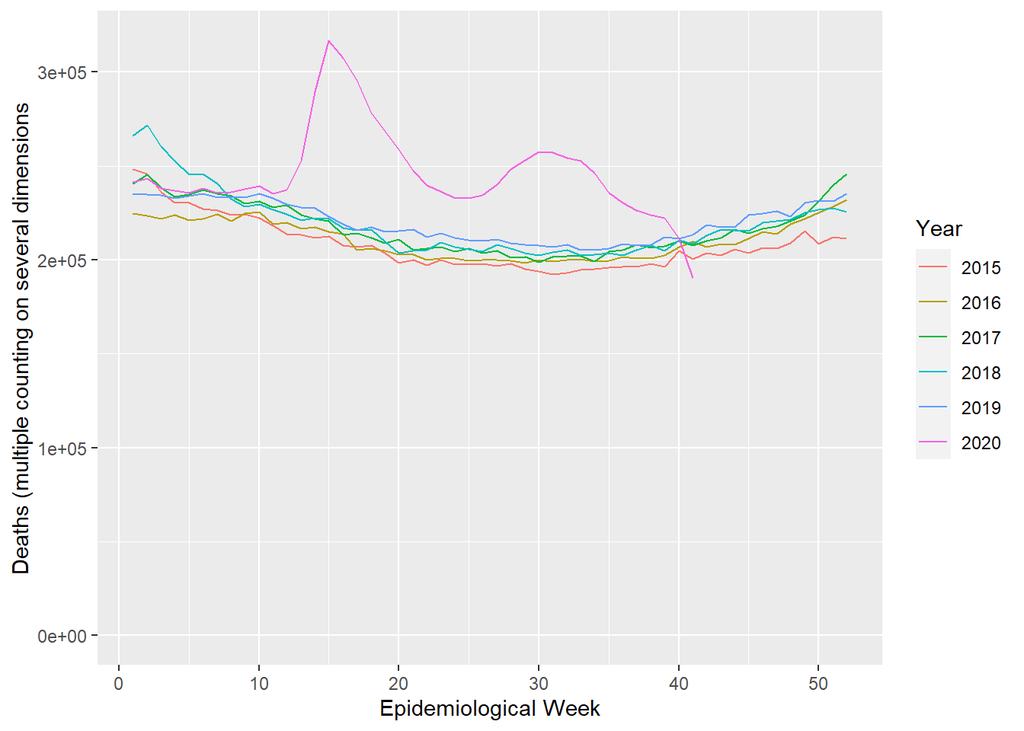

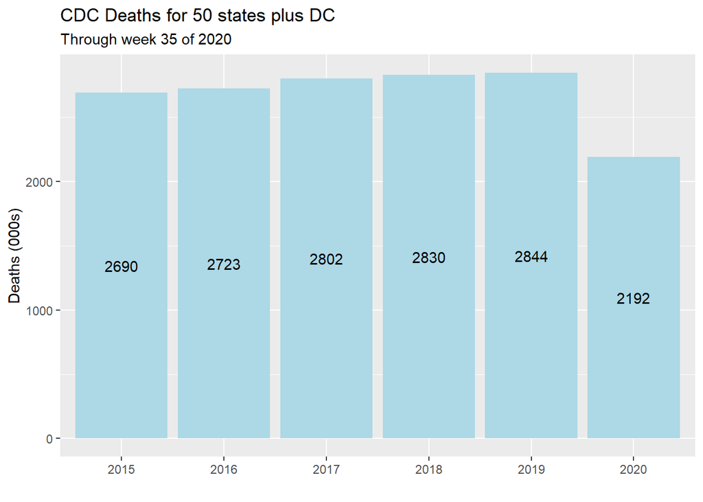

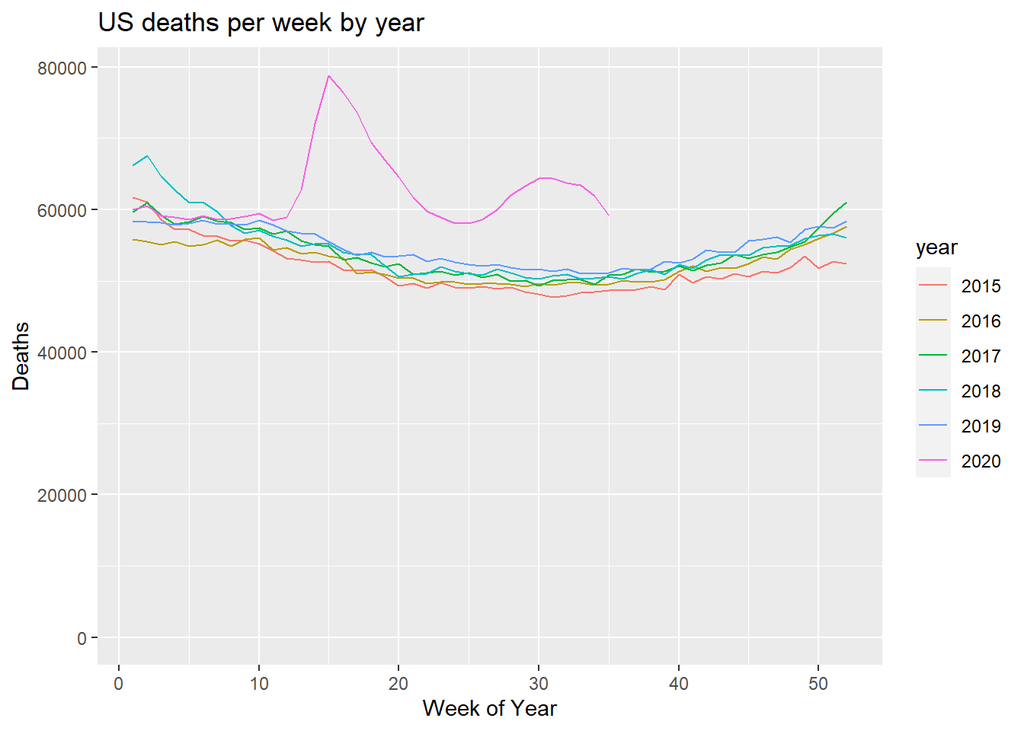

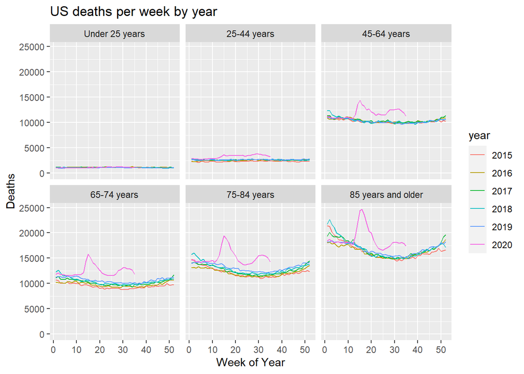

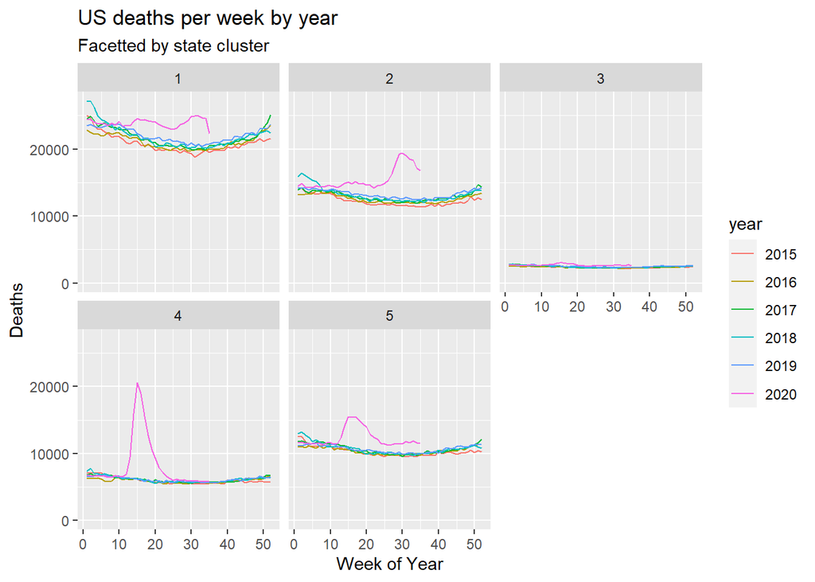

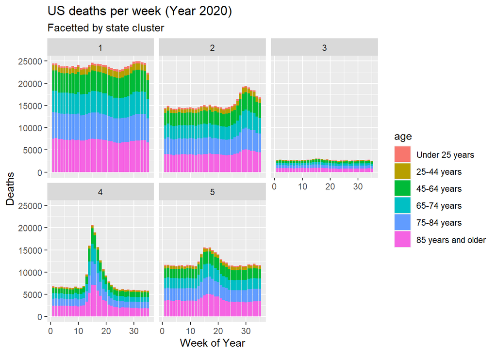

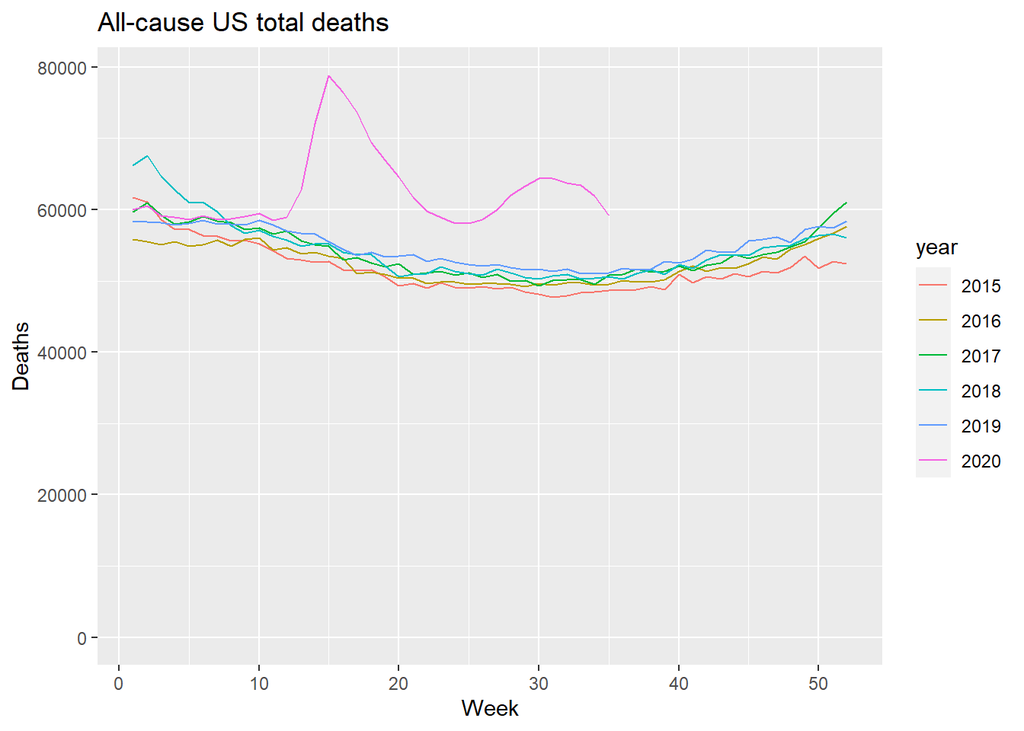

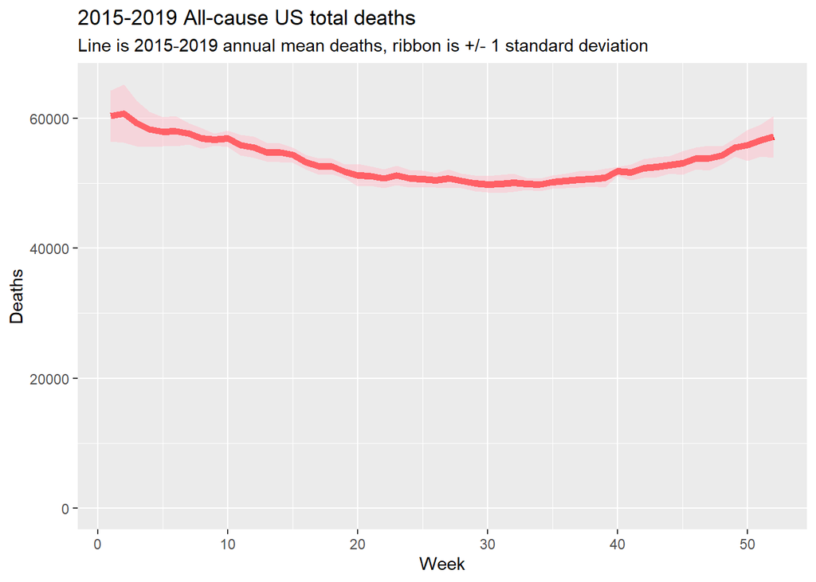

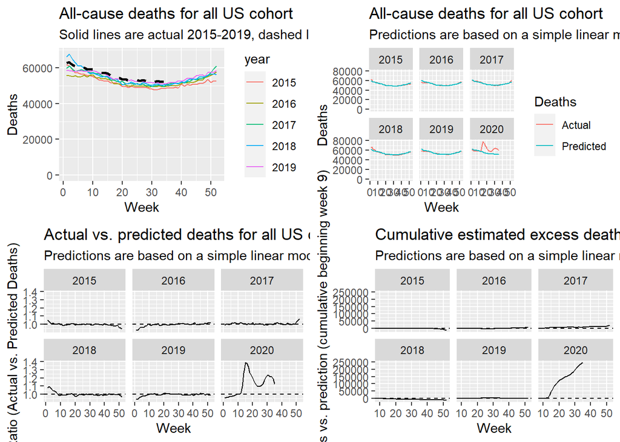

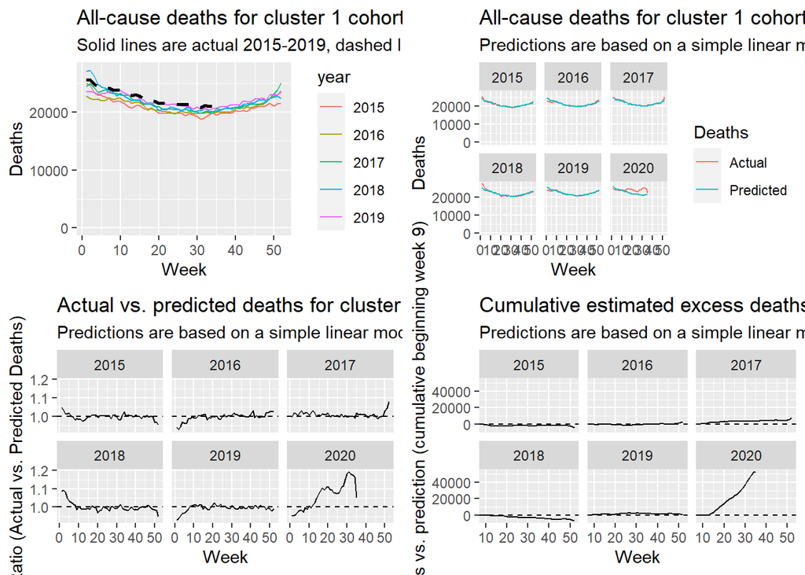

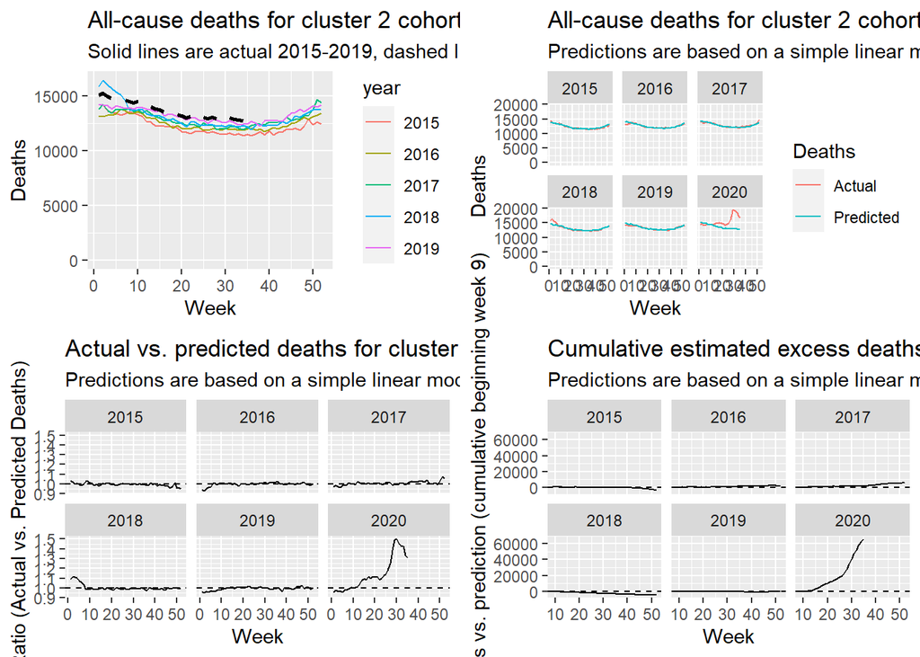

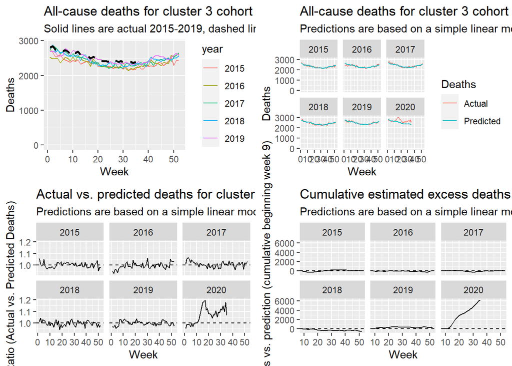

[19 more figures not shown]

```r
# Use data that have previously been downloaded
cdcLoc <- "Weekly_counts_of_deaths_by_jurisdiction_and_age_group_downloaded_20201027.csv"
cdcList_20201027 <- readRunCDCAllCause(loc=cdcLoc,
                                       startYear=2015,
                                       curYear=2020,
                                       weekThru=35,
                                       startWeek=9,
                                       lst=readFromRDS("test_hier5_201025"),
                                       epiMap=readFromRDS("epiMonth"),
                                       agePopData=readFromRDS("usPopBucket2020"),
                                       cvDeathThru="2020-08-29",
                                       cdcPlotStartWeek=10,
                                       dlData=FALSE
                                       )
```

#### *Saving key files as RDS*

```r
saveToRDS(cdcList_20201027, ovrWriteError=FALSE)
```